# ISLR_Ch4_LogisticRegression

Steve Newns

April 27, 2018

## 4.6.1 The Stock Market Data

Begin by examining some numerical + graphical summaries of `Smarket` data (`ISLR` library) = % returns for S&P 500 stock index over 1,250 days, from the beginning of 2001 until end of 2005. For each date, we have recorded the % returns for each of the 5 previous trading days, `Lag1` through `Lag5` + recorded `Volume` (# of shares traded on previous day, in billions), `Today` (% return on date in question) + `Direction` (whether market was Up/Down on this date)

```r
library(ISLR)
library(mosaic)
library(ggplot2)

names(Smarket)
```

```
## [1] "Year"      "Lag1"      "Lag2"      "Lag3"      "Lag4"      "Lag5"
## [7] "Volume"    "Today"     "Direction"
```

```r
dim(Smarket)
```

```
## [1] 1250    9
```

```r
summary(Smarket)
```

```
##       Year           Lag1                Lag2
##  Min.   :2001   Min.   :-4.922000   Min.   :-4.922000
##  1st Qu.:2002   1st Qu.:-0.639500   1st Qu.:-0.639500
##  Median :2003   Median : 0.039000   Median : 0.039000
##  Mean   :2003   Mean   : 0.003834   Mean   : 0.003919
##  3rd Qu.:2004   3rd Qu.: 0.596750   3rd Qu.: 0.596750
##  Max.   :2005   Max.   : 5.733000   Max.   : 5.733000
##       Lag3                Lag4                Lag5
##  Min.   :-4.922000   Min.   :-4.922000   Min.   :-4.92200
##  1st Qu.:-0.640000   1st Qu.:-0.640000   1st Qu.:-0.64000
##  Median : 0.038500   Median : 0.038500   Median : 0.03850
##  Mean   : 0.001716   Mean   : 0.001636   Mean   : 0.00561
##  3rd Qu.: 0.596750   3rd Qu.: 0.596750   3rd Qu.: 0.59700
##  Max.   : 5.733000   Max.   : 5.733000   Max.   : 5.73300
##      Volume           Today           Direction
##  Min.   :0.3561   Min.   :-4.922000   Down:602
##  1st Qu.:1.2574   1st Qu.:-0.639500   Up  :648
##  Median :1.4229   Median : 0.038500
##  Mean   :1.4783   Mean   : 0.003138
##  3rd Qu.:1.6417   3rd Qu.: 0.596750
##  Max.   :3.1525   Max.   : 5.733000
```

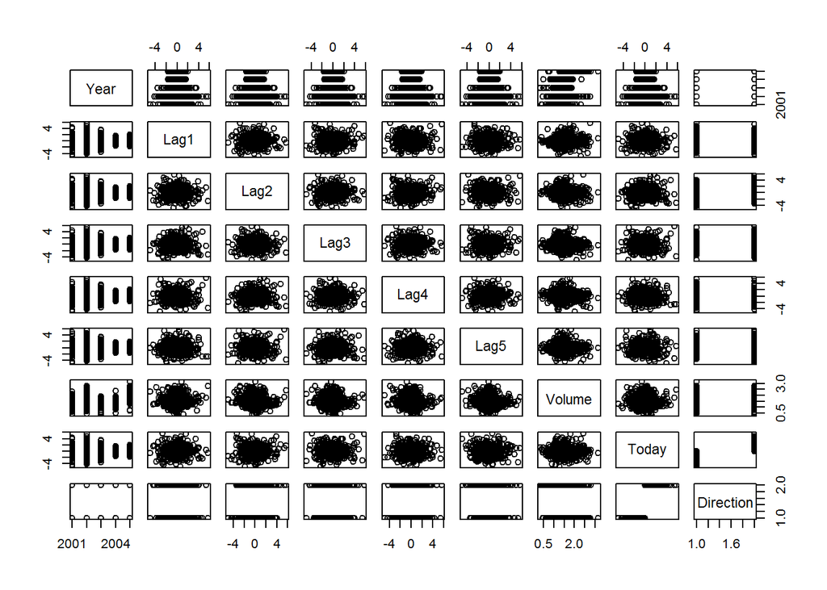

```r
pairs(Smarket)
```

`cor()` = produce matrix w/ all of pairwise correlations among predictors in a data set (ignoring `Direction` = qualitative)

```r
library(tidyverse)
library(corrplot)

Smarket[,1:8] %>%
  #select(Year,Lag1,Lag2,Lag3,Lag4,Lag5,Volume,Today) %>%
  cor()
```

```
##              Year         Lag1         Lag2         Lag3         Lag4
## Year   1.00000000  0.029699649  0.030596422  0.033194581  0.035688718
## Lag1   0.02969965  1.000000000 -0.026294328 -0.010803402 -0.002985911
## Lag2   0.03059642 -0.026294328  1.000000000 -0.025896670 -0.010853533
## Lag3   0.03319458 -0.010803402 -0.025896670  1.000000000 -0.024051036
## Lag4   0.03568872 -0.002985911 -0.010853533 -0.024051036  1.000000000
## Lag5   0.02978799 -0.005674606 -0.003557949 -0.018808338 -0.027083641
## Volume 0.53900647  0.040909908 -0.043383215 -0.041823686 -0.048414246
## Today  0.03009523 -0.026155045 -0.010250033 -0.002447647 -0.006899527
##                Lag5      Volume        Today
## Year    0.029787995  0.53900647  0.030095229
## Lag1   -0.005674606  0.04090991 -0.026155045
## Lag2   -0.003557949 -0.04338321 -0.010250033
## Lag3   -0.018808338 -0.04182369 -0.002447647
## Lag4   -0.027083641 -0.04841425 -0.006899527
## Lag5    1.000000000 -0.02200231 -0.034860083
## Volume -0.022002315  1.00000000  0.014591823
## Today  -0.034860083  0.01459182  1.000000000
```

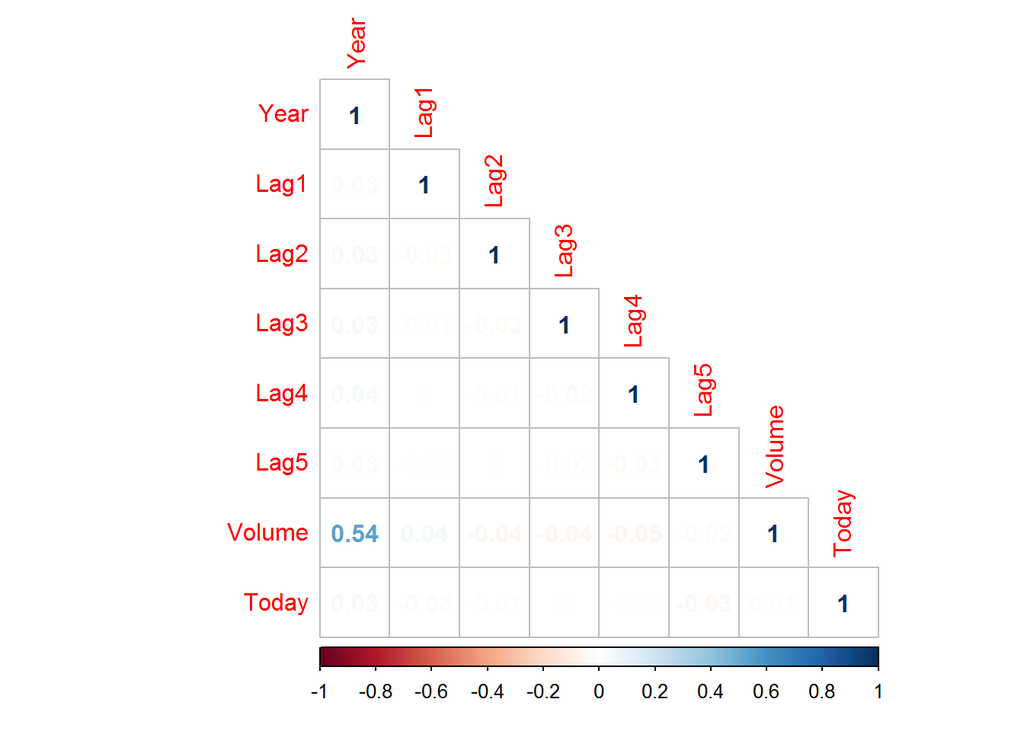

```r
corrplot(cor(dplyr::select(Smarket,-Direction),
                  use="pairwise.complete.obs"), method = "number", type = "lower")
```

As expected, correlations between `Lag` variables + today’s returns = ~0, so appears to be little correlation between today’s + previous days’ returns, w/ only substantial correlation = between `Year` and `Volume`.

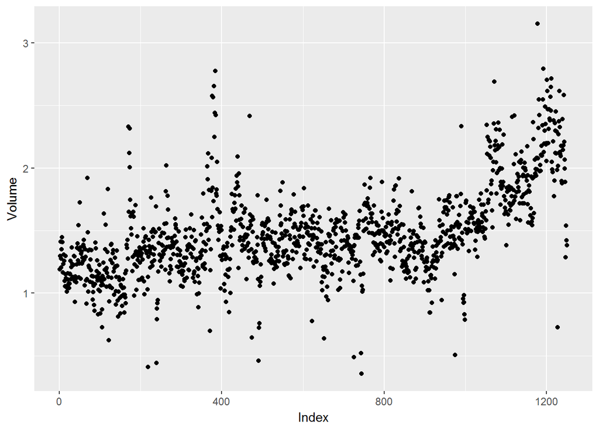

```r
Smarket %>%
  mutate(rowNum = as.numeric(row.names(Smarket))) %>%
  ggplot(aes(rowNum,Volume)) +
    geom_point() +
    labs(x="Index",main="Volume of trades over Time")
```

```r
#plot(Smarket$Volume)
```

## 4.6.2 Logistic Regression

Next, we will fit a logistic regression model in order to predict `Direction` using `Lag1`-`Lag5` + `Volume` via `glm()` = fits **generalized linear models** (*class of models* that includes logistic regression)

- like `lm()` but must pass in argument `family=binomial` for a logistic regression rather than some generalized linear model

```r
glm_fit <- glm(Direction ~ . - Year - Today, Smarket, family = "binomial")
msummary(glm_fit)
```

```
## Coefficients:
##              Estimate Std. Error z value Pr(>|z|)
## (Intercept) -0.126000   0.240736  -0.523    0.601
## Lag1        -0.073074   0.050167  -1.457    0.145
## Lag2        -0.042301   0.050086  -0.845    0.398
## Lag3         0.011085   0.049939   0.222    0.824
## Lag4         0.009359   0.049974   0.187    0.851
## Lag5         0.010313   0.049511   0.208    0.835
## Volume       0.135441   0.158360   0.855    0.392
##
## (Dispersion parameter for binomial family taken to be 1)
##
##     Null deviance: 1731.2  on 1249  degrees of freedom
## Residual deviance: 1727.6  on 1243  degrees of freedom
## AIC: 1741.6
##
## Number of Fisher Scoring iterations: 3
```

Smallest $p$-value here is associated w/ `Lag1` + negative coefficient suggests if the market had a positive return yesterday, it is less likely to go up today. However, at a value of 0.15, the $p$-value is still relatively large, and so there is no clear evidence of a real association between `Lag1` and `Direction`.

`coef()` accesses just the coefficients for this fitted model + `msummary()` access particular aspects of the fitted model, such as the $p$-values for the coefficients

```r
coef(glm_fit)
```

```
##  (Intercept)         Lag1         Lag2         Lag3         Lag4
## -0.126000257 -0.073073746 -0.042301344  0.011085108  0.009358938
##         Lag5       Volume
##  0.010313068  0.135440659
```

```r
summary(glm_fit)$coef
```

```
##                 Estimate Std. Error    z value  Pr(>|z|)
## (Intercept) -0.126000257 0.24073574 -0.5233966 0.6006983
## Lag1        -0.073073746 0.05016739 -1.4565986 0.1452272
## Lag2        -0.042301344 0.05008605 -0.8445733 0.3983491
## Lag3         0.011085108 0.04993854  0.2219750 0.8243333
## Lag4         0.009358938 0.04997413  0.1872757 0.8514445
## Lag5         0.010313068 0.04951146  0.2082966 0.8349974
## Volume       0.135440659 0.15835970  0.8552723 0.3924004
```

```r
summary(glm_fit)$coef[,4] # just p-values
```

```
## (Intercept)        Lag1        Lag2        Lag3        Lag4        Lag5
##   0.6006983   0.1452272   0.3983491   0.8243333   0.8514445   0.8349974
##      Volume
##   0.3924004
```

`predict()` = predict probability market will go up, given values of the predictors w/ `type="response"` to output probabilities of the form $P(Y = 1|X)$, as opposed to other info, such as the **logit**

- If no data set is supplied to `predict()`, probabilities are computed for the *training* data used to fit the model.

```r
glm_probs <- predict(glm_fit,type="response") # no newdata arg =  predict probability on training data used to fit model
head(glm_probs)
```

```
##         1         2         3         4         5         6
## 0.5070841 0.4814679 0.4811388 0.5152224 0.5107812 0.5069565
```

We know these values correspond to the probability of market going *up*, rather than down, b/c `contrasts()` indicates R has created a dummy variable w/ 1 = Up

```r
contrasts(Smarket$Direction)
```

```
##      Up
## Down  0
## Up    1
```

To make a prediction as to whether the market will go up/down on a particular day, must convert predicted probabilities into class labels, `Up` or `Down`, w/in a vector of class predictions based on whether predicted probability of a market increase is > or < 0.5 (or some other chosen threshold)

```r
glm_preds <- rep("Down",1250)   # create vector of '1250' Down elements.
glm_preds[glm_probs>.5] <- "Up" # set value of records  where p > .5 to 'Up'
(cm <- table(glm_preds,Smarket$Direction)) # confusion matrix
```

```
##
## glm_preds Down  Up
##      Down  145 141
##      Up    457 507
```

```r
sensitivity <- cm[1] / (cm[2] + cm[1]) # true positive rate = TP / (TP + FN)
specificity <- cm[4] / (cm[4] + cm[3]) # recall = true negative rate = TN / (TN + FP)
precision <- cm[1] / (cm[1] + cm[3]) # TP / predicted Pos
accuracy <- (cm[4]+cm[1]) / sum(cm) # TP + TN / n OR  mean(glm_preds==Direction)

#cat("\nFOR PREDICTING DOWN:")
#cat("\nSensitivity (TP rate or Recall): ",sensitivity)
#cat("\nSpecificity (TN rate): ",specificity)
#cat("\nPrecision (Positive Predictive Value): ",precision)
#cat("\nAccuracy: ",accuracy) # mean(glm_preds==Direction)

library(caret)

confusionMatrix(as.factor(glm_preds), Smarket$Direction)
```

```
## Confusion Matrix and Statistics
##
##           Reference
## Prediction Down  Up
##       Down  145 141
##       Up    457 507
##
##                Accuracy : 0.5216
##                  95% CI : (0.4935, 0.5496)
##     No Information Rate : 0.5184
##     P-Value [Acc > NIR] : 0.4216
##
##                   Kappa : 0.0237
##  Mcnemar's Test P-Value : <2e-16
##
##             Sensitivity : 0.2409
##             Specificity : 0.7824
##          Pos Pred Value : 0.5070
##          Neg Pred Value : 0.5259
##              Prevalence : 0.4816
##          Detection Rate : 0.1160
##    Detection Prevalence : 0.2288
##       Balanced Accuracy : 0.5116
##
##        'Positive' Class : Down
##
```

```r
cat("\nTraining Error Rate: ", 1 - accuracy) # mean(glm_test_preds!=Direction)
```

```
##
## Training Error Rate:  0.4784
```

Diagonal elements of a confusion matrix = *correct* predictions, while off-diagonals = *incorrect*. Hence our model correctly predicted market would go up on 507 days + correctly predicted it would go down on 145 days, for a total of 507 + 145 = 652 correct predictions = correct 52.2% of the time.

At first glance, it appears the logistic regression model is working a little better than random guessing (50%). **However, this result is misleading** b/c we trained + tested on the *same set* of 1250 observations. **In other words, 100% - 52.2% = 47.8% = the *TRAINING* error rate, which is often *overly optimistic* as it tends to *underestimate* TEST error rate.**

To better assess model accuracy: fit the model using *subset* of the data + then examine how well it predicts using *held out data* = will yield a more realistic error rate, in the sense that, in practice, we’re interested in model’s performance *out-of-sample*, and *not* on training data (i.e. days in the future for which market’s movements are unknown)